# AY22/23 Sem 2 DSA2101 Group Project

Income and Wealth Group 1

Authors:

A Muhammed Madhih

A.Guhanavel S/O Ashok Kumar

Darryl Chan

Shonn Tan

Soo Wen Qiao

```r
#Installing relevant packages
library(tidyverse)
library(readxl)
library(stringr)
library(lubridate)
library(ggplot2)
library(gtable)
library(gridExtra)
library(grid)
library(viridis)
library(distill)
```

# 1 Introduction

Wealth and Income is a collection of datasets that provides data related to how income inequality, homeownership rates, retirement savings, student loan debt, asset-building subsidies have all contributed to growing wealth disparities in America. We are going to explore how one’s socioeconomic backgrounds make it apparent that wealth, debt and several other factors play a role in their success.

# 2 Descriptive Statistics (Data Cleaning)

Note: Some .csv files contained traces of missing information or duplicated rows. Our findings are shown below.

```r
# Reading of datasets
lifetime_earn <- read.csv('https://raw.githubusercontent.com/rfordatascience/tidytuesday/master/data/2021/2021-02-09/lifetime_earn.csv')
student_debt <- read.csv('https://raw.githubusercontent.com/rfordatascience/tidytuesday/master/data/2021/2021-02-09/student_debt.csv')
retirement <- read.csv('https://raw.githubusercontent.com/rfordatascience/tidytuesday/master/data/2021/2021-02-09/retirement.csv')
home_owner <- read.csv('https://raw.githubusercontent.com/rfordatascience/tidytuesday/master/data/2021/2021-02-09/home_owner.csv')
race_wealth <- read.csv('https://raw.githubusercontent.com/rfordatascience/tidytuesday/master/data/2021/2021-02-09/race_wealth.csv')
income_time <- read.csv('https://raw.githubusercontent.com/rfordatascience/tidytuesday/master/data/2021/2021-02-09/income_time.csv')
income_limits <- read.csv('https://raw.githubusercontent.com/rfordatascience/tidytuesday/master/data/2021/2021-02-09/income_limits.csv')
income_aggregate <- read.csv('https://raw.githubusercontent.com/rfordatascience/tidytuesday/master/data/2021/2021-02-09/income_aggregate.csv')
income_distribution <- read.csv('https://raw.githubusercontent.com/rfordatascience/tidytuesday/master/data/2021/2021-02-09/income_distribution.csv')
income_mean <- read.csv('https://raw.githubusercontent.com/rfordatascience/tidytuesday/master/data/2021/2021-02-09/income_mean.csv')
```

```r
datasets = list(lifetime_earn, student_debt, retirement, home_owner, race_wealth, income_time, income_limits, income_aggregate, income_distribution, income_mean)
datasets_name = c("lifetime_earn", "student_debt", "retirement", "home_owner", "race_wealth", "income_time", "income_limits", "income_aggregate", "income_distribution", "income_mean")
check <- data.frame(name = character(), contains_NA = logical(), num_duplicates = integer(),
                 stringsAsFactors = FALSE)
for (i in 1:length(datasets)) {
    name = datasets_name[i]
    dataset = datasets[[i]]

    #Check for NA in datasets
    contain_NA = any(is.na(dataset))

    #Check for duplicates
    num_duplicates = sum(duplicated(dataset))

    #Binds everything together into another dataset
    check <- rbind(check, data.frame(name = name, contains_NA = contain_NA, num_duplicates = num_duplicates))
}
head(check, n = 10)
```

|  | name | contains_NA | num_duplicates |
| --- | --- | --- | --- |
| 1 | lifetime_earn | FALSE | 0 |
| 2 | student_debt | FALSE | 0 |
| 3 | retirement | FALSE | 0 |
| 4 | home_owner | FALSE | 0 |
| 5 | race_wealth | TRUE | 0 |
| 6 | income_time | FALSE | 0 |
| 7 | income_limits | FALSE | 0 |
| 8 | income_aggregate | FALSE | 0 |
| 9 | income_distribution | TRUE | 0 |
| 10 | income_mean | FALSE | 2 |

# 3 Question 1: How is wealth inequality linked to racial inequality?

## 3.1 Introduction

The United States of America (USA) has had a history of racially discriminatory events with slavery and Jim Crow laws, which disproportionately affected minority races and tied one’s wealth accumulation with their races (Blackmore, 2021). The civil rights movements have removed many discriminatory practices, but the topic of institutionalized racial discrimination has been brought back to attention with the recent Black Lives Matter movement. Examining racial inequality helps us understand how race is symbolized in society and it will be a good case study for multi-racial society such as Singapore. To investigate if the level of racial inequality has remained largely present or has improved over the years, we would study the relationship between race and a person’s socio-economic standing. The two ways to study these would be to investigate student debt and intra-racial wealth inequality over the years, with respect to races from blacks, hispanics and whites demographics. This review could help policymakers identify areas for improvement towards racial equality and equity.

We will be using these datasets :  
1. `student_debt.csv`  
2. `race_wealth.csv`  
to answer this question.

## 3.2 Methodology

### 3.2.1 Visualization 1: Relationship Between Racial Classes and Student Debt across the years

We will need to look at the different columns in the `student_debt` dataset. A quick summary of the dataset is that it contains several important columns such as the year, race, loan_debt and loan_debt_pct. `loan_debt_pct` will allow us to note the share of families with student loan debt. The data is relatively clean. For the first plot, we added additional breaks in between the default grids to make the plot more meaningful. We tried to incorporate all of the given variables of the dataset, at the same time, not leaving the plot cluttered with lots of information and values. Initially, we just had `loan_debt` vs race. But we also decided to use `loan_debt_pct` as a size variable. However, we were not able to read the size of circles from just a view. Hence, we decided to call out the actual percentages on the plot. Moreover, with the custom coloring, viewers will be able to register the message easily by associating the trend and numbers to the associated race. Through all four variables, one would be able to note the trend of student debt across the years between different races, also reinforcing the percentage of a specifc race that has taken up loan for the specific year. We can see which race has the most loan and the wealth inequality increasing over time.

### 3.2.2 Visualization 2: Relationship Between Racial Classes and Family Wealth across the years

The dataset `race_wealth` has columns: type, year, race and wealth_family, where “type” specifically indicates the measures (average and median) for racial family wealth and “wealth_family” indicates racial family wealth. We filtered the “average” to present the dataset fairly and relatively cleaned the dataset, observing it contains some missing value. We also added the family wealth percentage for better trend visualisation. We used barplot and inlayed each family wealth with its percentage. Later, we scaled y by ten thousand dollars as unit. To emphasise the significant drop of family wealth in 2010 and 2013, we added a line segment and speculated it was influenced by the 2008 recession. From the plot, one can observe that whites have a dominance in family wealth over years. Although family wealth increases by times, we noticed that the proportion of wealth remained unevenly distributed and this remained the economic structure unstable. The unstable status of economic structure may rose to racial issue when the tough times (such as the retrenchment owed to Covid-19) come.

## 3.3 Visualization 1: A Plot to Show Relationship Between Racial Classes and Student Debt across the years

### 3.3.1 Code block for producing plot (cleaning included)

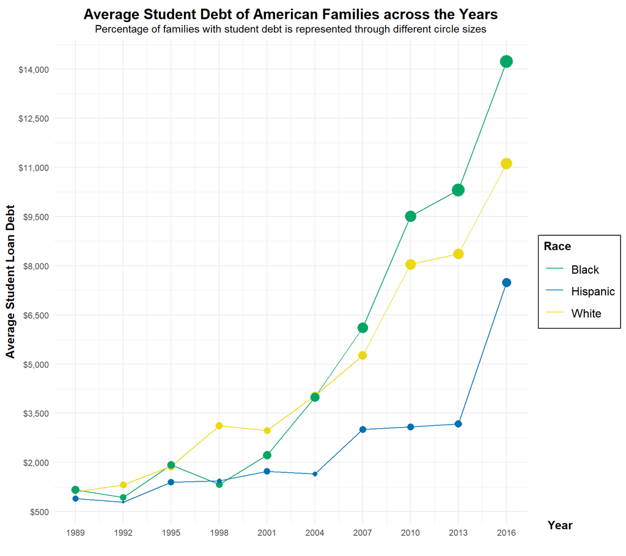

```r
# Reordering the race column to have factors being ordered as Black, White and Hispanic as the order
student_debt = mutate(student_debt, race = fct_relevel(race,"Black", "Hispanic", "White"))
# Base ggplot command using x as the year and y as the loan_debt
# We also have group and color as race where different colors will be used for race and race will also be grouped
ggplot(student_debt,
    aes(x = year,
        y = loan_debt,
        colour = race)) +
 # Plotting of line using geom_line
    geom_line(aes(),
            linewidth = 0.5) +

# Adding points at int years based on their percentage debt
    geom_point(aes(size = loan_debt_pct * 200),
             show.legend = FALSE) +

# Background of plot to minimal and performing some manual adjustments for aesthetic look
    theme_minimal() + theme(plot.subtitle = element_text(hjust = 0.5),
                            plot.title = element_text(hjust = 0.5, vjust = 0, face = "bold", size = 15),
                            axis.title.x = element_text(hjust = 1.1, vjust =10, face = "bold", size = 12),
                            axis.title.y = element_text(hjust = 0.5, vjust = 1, face = "bold", size = 12),
                            legend.title = element_text(hjust = 0, vjust = 0.8, face = "bold", size = 12),
                            legend.text = element_text(hjust = 0, vjust = 0.45, face = "plain", size = 12),
                            legend.key.size = unit(0.8, "cm"),
                            legend.background = element_rect(linewidth = 0.5, linetype = "solid", colour = "black")) +

# Adding more breaks in axis scales to make it look more continuous
    scale_x_continuous(breaks = seq(1989, 2016, 3)) +
    scale_y_continuous(breaks = seq(500, 15000, 1500),
                       labels = scales::dollar) +
# Following a standard colour scale
    scale_color_manual(values = c("White" = "#ECD715", "Black" = "#00A567", "Hispanic" = "#0370B2")) +


# Addition of labels and other titles about the plot
    labs(title="Average Student Debt of American Families across the Years",
         color = NULL,
         x = "Year", y = "Average Student Loan Debt",
         subtitle ="Percentage of families with student debt is represented through different circle sizes") +
    guides(color=guide_legend(title="Race"))
```

### 3.3.2 Discussion for Visualisation 1

In this graph, we see that student debt is increasing for all three races, this is due to higher college enrollments and more people taking up student loans as college education is becoming more popular (Hoffower, 2018). However, the average student debt of black families can be seen overtaking white families after 2004. Additionally, black families have the highest increase in percentage of families with student debt. This is because black families, on average, carry less wealth and inheritance due to previously stated historical reasons and are also less likely to graduate on time (National Center for Education Statistics, 2021), which in turn forces black people to take up more student loans. Hence, these reasons compound the rapidly rising black student debt. Contrary to our expectations, Hispanics have the lowest student debt, this could be due to a cultural phenomenon where they are more reluctant to take up loans to pay off tuition fees (Rivera, 2022). However, the low student debt may not be an indicator for low wealth inequality as they could be struggling to pay off tuition fees without taking up loans. Overall, this graph shows that one is more likely to be indebted if they are black, which suggests that previous and current racial discriminatory practices could still be hampering the progress of black people.

## 3.4 Visualisation 2 : A Plot using `race_wealth.csv` to Show Relationship between Racial Classes and Wealth Inequality across the years

### 3.4.1 Code block for producing plot (cleaning included)

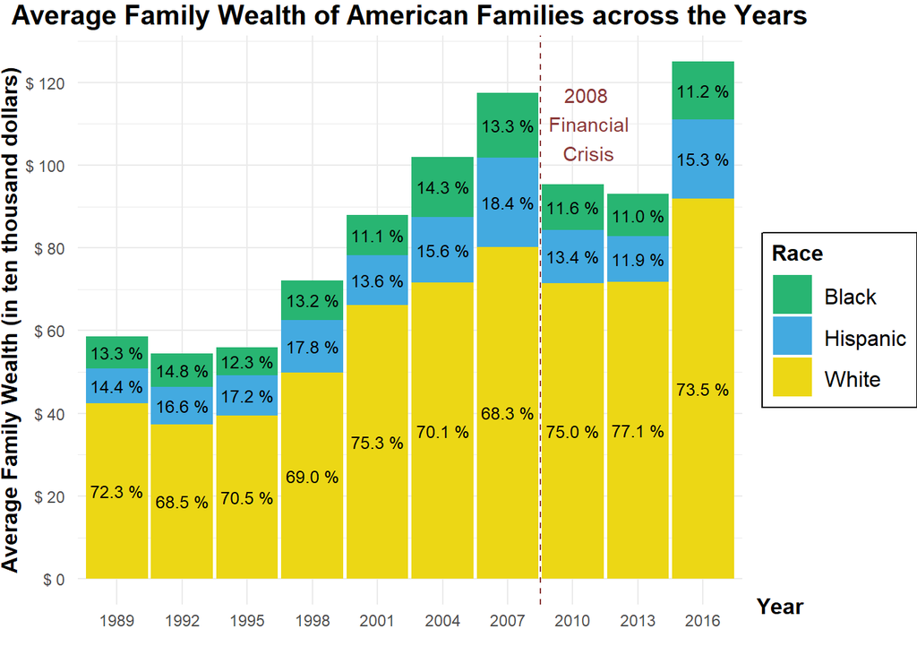

```r
# Cleaning the dataset by omitting NA values and filtering the conditions
# The race type focus here is "White", "Black" and "Hispanic", year range was constrained to 1989-2016
race_wealth2 = race_wealth %>%
    filter(type == "Average",
           race %in% c("White", "Black", "Hispanic"),
           !year %in% c(1963,1983)) %>%
    na.omit() %>%
    select(-type) %>%
    rename(Race = race) %>%
    group_by(year) %>%
    mutate(family_wealth_pct = (wealth_family / sum(wealth_family)*100),
           total_family_wealth_per_year = sum(wealth_family)) %>%
    mutate(Race = as.factor(Race), year = as.factor(year)) %>%
    ungroup()


# Plot on relatively cleaned dataset, x as year and y as family wealth, grouped by race and year unit is 3 year
ggplot(race_wealth2, aes(x= year, y=wealth_family, fill=Race)) +

# Use stacked geom_bar and widen the bars' width
    geom_bar(position="stack", stat="identity", width = 0.95) +

# Add on percentages for each distinct family wealth
    geom_text(aes(label = paste0(sprintf("%1.1f", family_wealth_pct), " %")),
              position = position_stack(vjust = 0.5), size = 3.25) +

# Add the title, x axis and y axis labels
    labs(title = "Average Family Wealth of American Families across the Years",
         x = "Year", y = "Average Family Wealth (in ten thousand dollars)")+

# Add the red breakline to indicate the reason of overall drop in racial family wealth
    geom_segment(aes(x = 7.5, xend = 7.5, y = -Inf, yend = Inf), linetype = "dashed", color = "indianred4", size = 0.5) +

# Annotate the reason "2008 financial crisis"
    annotate("text", x = 8.2, y = 1100000, label = "2008\n Financial\n Crisis", colour = "indianred4") +

# Break y values by 200000, add observation unit "$" for y axis and scaled y values with 1*10^(-4)
    scale_y_continuous(breaks = seq(0, 1250000, by = 200000),
                       labels = scales::label_dollar(scale = 1e-4, prefix = "$ ", suffix = " ")) +

# Add the theme for plot, x axis, y axis and legend
    theme_minimal() + theme(plot.title = element_text(hjust = 0.5, vjust = 0.3, face = "bold", size = 15),
                            plot.margin = margin(0,0,0,0,"cm"),
                            axis.title.x = element_text(hjust = 1.1, vjust =10, face = "bold", size = 12),
                            axis.title.y = element_text(hjust = 0.5, vjust = 1, face = "bold", size = 12),
                            legend.title = element_text(hjust = 0, vjust = 0.8, face = "bold", size = 12),
                            legend.text = element_text(hjust = 0, vjust = 0.45, face = "plain", size = 12),
                            legend.key.size = unit(0.8, "cm"),
                            legend.background = element_rect(linewidth = 0.5, linetype = "solid", colour = "black")) +

# Following a standard colour scale
  scale_fill_manual(values = c("White" = "#ECD715", "Black" = "#28B572", "Hispanic" = "#43AAE0"))
```

### 3.4.2 Discussion for Visualisation 2

This graph shows the percentage wealth of Americans within races is largely stable and generally growing, but between 2007 and 2010, there is a drop in the wealth of Americans which can be attributed to the 2008 financial crisis. Comparing the two minorities’ data their percentage wealth shrank from 32% to 25% and the years preceding the recession, the two minorities group were not able to regain the pre-recession wealth percentage. This could mean that minorities are more adversely affected by recessions as they have less economic security (Traus, 2016). Additionally, despite removing many discriminatory laws many years prior, the wealth distribution of the minority groups has not significantly caught up, which could mean that systematic issues persists in society that are hampering their growth. Hence, this data shows that one is more likely to face financial difficulty if they are from a minority group. However, additional data such as Asian or Native-Americans demographics data would be needed to give us a better understanding of the link between race and wealth.

# 4 Question 2: Has the standard of living been improving over time for citizens of the USA?

## 4.1 Introduction

The United States of America (USA) has been ranked the highest for its Gross Domestic Product (GDP) for the past 60 years (Knoema, 2021). GDP is a common metric used to measure a country’s wealth, and it is undoubtedly clear that the USA is a wealthy country. However, was the USA able to use its accumulated wealth to enhance the living standards of its population? The answer to this question is essential as standards of living improvements has been linked to social and political stability (United Nations, 2019). Hence, we would like to investigate whether there has been an increase in the standards of living of American citizens. If so, how much has it improved and are the progressions equal or proportional to all segments of American society? This investigation will help identify areas where intervention is necessary to improve the living standards of vulnerable segments of society, which will help policymakers make informed decisions that can positively impact society. Thus we will be studying the Average income of different segments of American society and also the income distribution of American families over the years, which is related to the study of standards of living (Conceição 2019).

We will be using these datasets :  
1. `income_mean`  
2. `income_distribution`  
to answer this question.

## 4.3 Visualization 1

### 4.3.1 Code block for producing plot (cleaning included)

[figure not shown]

```r
# Removing duplicate data and tidying
income_mean_tidy = distinct(income_mean) %>%
    distinct() %>%
    filter(race == "All Races") %>%
    filter(dollar_type == "Current Dollars") %>%
    mutate(income_dollars = round(income_dollars/1000, 0), income_quintile = factor(income_quintile)) %>%
    mutate(income_quintile = recode(income_quintile, "Highest" = "Upper", "Fourth" = "Upper-Mid", "Second" = "Lower-Mid", "Lowest" = "Lower"))

# Mean income throughout the years regardless of income_quintile
income_mean_tidy_avg = group_by(income_mean_tidy, year) %>%
    summarize(income_dollars = round(mean(income_dollars),0))

# Labels for graph
income_mean_tidy2 = filter(income_mean_tidy, year == 2019)

# Plotting
options(scipen = 1000)
ggplot(income_mean_tidy,
       aes(x = year,
           y = income_dollars,
           color = income_quintile)) +

# Add solid lines
    geom_line(aes(),
              size = 1,
              linetype = "solid") +

# Separating the lines
    scale_color_viridis(discrete = TRUE,
                        breaks = c("Top 5%", "Upper", "Upper-Mid", "Middle", "Lower-Mid", "Lower") ,
                        label = c("Top 5%", "Upper", "Upper-Mid", "Middle", "Lower-Mid", "Lower"),
                        guide = "none") +

# Break y values from 0 to 500 dollars with 50 dollar per interval
    scale_y_continuous(breaks = seq(0, 500, 50), labels = scales::dollar) +

# Break x values from the year 1967 to 2025 with the interval of 10 years
    scale_x_continuous(limits = c(1967, 2025), breaks = c(1970, 1980, 1990, 2000, 2010, 2020)) +

# Add the theme for plot, x axis, y axis and legend
    theme_minimal() + theme(plot.subtitle = element_text(hjust = 0.5),
                            plot.title = element_text(hjust = 0.5, vjust = 0, face = "bold", size = 15),
                            axis.title.x = element_text(hjust = 1.1, vjust =10, face = "bold", size = 12),
                            axis.title.y = element_text(hjust = 0.5, vjust = 1, face = "bold", size = 12),
                            legend.title = element_text(hjust = 0, vjust = 0.8, face = "bold", size = 12),
                            legend.text = element_text(hjust = 0, vjust = 0.45, face = "plain", size = 12),
                            legend.key.size = unit(0.8, "cm"),
                            legend.background = element_rect(linewidth = 0.5, linetype = "solid", colour = "black")) +

# Add the title, subtitle, x axis and y axis labels
    labs(title="Average income of American families throughout the years",
         x = "Year", y = "Income in USD (in thousands)",
         subtitle ="Of different social classes (Adjusted to 2021 CPI)", col = "Income Class") +

# Add labels to at the end of each line
    geom_text(data = income_mean_tidy2, aes(label = income_quintile),
              hjust = "left", nudge_x = 0.5, size = 3.0, color = "black", fontface = "bold")
```

### 4.3.2 Discussion for Visualisation 1

We can see that in the 1970s, the difference between the top 5% of annual salary and the bottom percentile was within 50,000 USD. However, in 2019, the absolute difference in annual salary is more than 400,000 USD. Moreover, we can see that the growth in annual income for the Top 5% and Upper class appears to be exponential while the salary increment for the lower classes appears marginal. This shows that the income disparity between the rich and the poor is widening at an exponential rate. Hence, suggesting to readers that the standards of living have improved for the rich, while it stagnated for the poor. The graph also suggests that income inequality is also widening at an exponential rate. However, this graph is ultimately unable to capture information such as socio-economic movements between classes. Additionally, there could be external factors which may contribute to the trend shown in this graph. For example, there are increasingly more low-wage workers entering the workforce, which deflates low income salaries (Autor & Wasserman, 2013) and executives having exorbitant salaries, which inflates the top 5% salaries (Mishel & Schieder, 2016). Both of these could contribute significantly to the dramatic income inequality shown in the graph.

## 4.4 Visualization 2

### 4.4.1 Code block for producing plot (cleaning included)

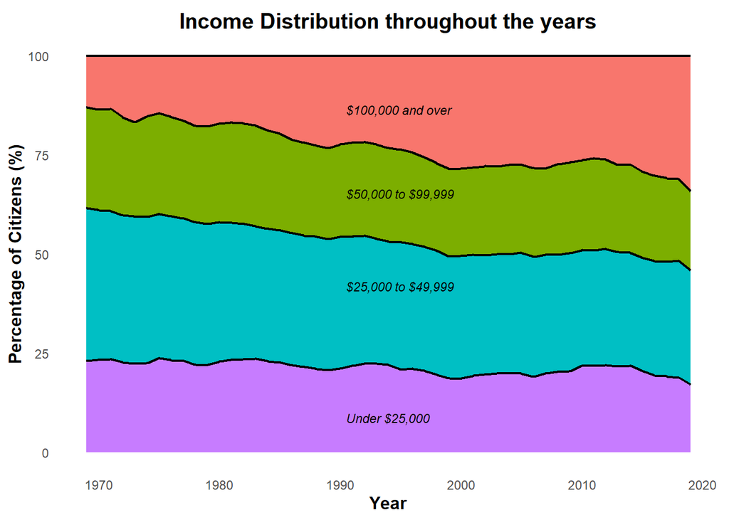

```r
# filter by all races % ensure the distribution precentage is out of 100
income_distribution_tidy = income_distribution %>%
                            filter(race == "All Races") %>%
                            na.omit() %>%
                            group_by(year) %>%
                            mutate(sum_of_dis = sum(income_distribution),
                                   aggreated_score = (income_distribution/sum_of_dis) *100) %>%
                            # select only year, income_bracket and aggregated score
                            select(year,income_bracket,aggreated_score)

# Readjust income bracket
income_distribution_tidy = income_distribution_tidy %>%
                            spread(income_bracket,aggreated_score) %>%
                        ungroup() %>%
                        mutate("$100,000 and over" = `$150,000 to $199,999` + `$100,000 to $149,999` + `$200,000 and over`,
                               "$50,000 to $99,999"  = `$75,000 to $99,999` + `$50,000 to $74,999`,
                              "$25,000 to $49,999" =  `$35,000 to $49,999` + `$25,000 to $34,999`,
                              "Under $25,000" = `Under $15,000`+ `$15,000 to $24,999`) %>%
                        select(year,"$100,000 and over","$50,000 to $99,999","$25,000 to $49,999","Under $25,000") %>%
                        gather(income_bracket,Distribution,2:5)


income_distribution_tidy_2 = income_distribution_tidy %>%
                            filter(year == "1990") %>%
                            mutate(income_bracket = as.factor(c("Under $25,000","$25,000 to $49,999","$50,000 to $99,999","$100,000 and over"))) %>%
                            mutate(cum_sum = cumsum(Distribution), Distribution = cum_sum)

ggplot(income_distribution_tidy, aes(x = year, y = Distribution, fill = income_bracket)) +
    geom_area(position = 'stack', colour= "black" , size=0.75) +
    scale_x_continuous(limits = c(1969,2019)) +
    theme_minimal() + theme(panel.grid.major = element_blank(), panel.grid.minor = element_blank()) +
    theme(plot.title = element_text(hjust = 0.5, vjust = 0, face = "bold", size = 15),
          legend.position = "none",
          axis.title.x = element_text(hjust = 0.5, vjust = 1, face = "bold", size = 12),
          axis.title.y = element_text(hjust = 0.5, vjust = 1, face = "bold", size = 12)) +

# Add labels
labs(title = "Income Distribution throughout the years", x = "Year", y = "Percentage of Citizens (%)") +

geom_text(data = income_distribution_tidy_2, aes(label = income_bracket),
          hjust = "left", vjust = 6, nudge_x = 0.5, size = 3.0, color = "black", fontface = "italic")
```

### 4.4.2 Discussion for Visualization 2

The second visualization is a stacked area graph that shows the proportion of American citizens according to their annual salaries over the years. This chart aims to help us visualize the changes in socio-economic status of Americans from the 1960s to 2019, which was one of the limitations of the first graph. A larger area and smaller area means a higher and lower distribution respectively. The distribution of the topmost category has grown significantly, while the two categories in the middle have decreased over the years. This indicates an upward shift in the proportion of middle-income to higher-income earners. However, the bottom category appears relatively stagnant with a slight drop towards 2020, which suggests a minimal change in the proportion of low-income Americans. Therefore, this indicates inequality in the improvement rate of living standards for low-income and middle to high-income Americans. Despite that, we require state-level data to have a clearer judgement of the improvement rates as the USA consists of 50 different states, each with unique demographics. For illustration, a person living in New York with an annual salary of 50,000 USD might be considered poor while a person living in Arkansas with the same salary is considered middle-income. This is because New York is a financial centre with high living costs and Arkansas is largely rural with low living costs respectively (StatsAmerica, 2021). Furthermore, people could move between states while keeping their salaries, which would mean standards of living variation without change in income.

# 5 References

Autor, D., & Wasserman, M. (2013, March). Wayward sons: The emerging gender gap in labor markets and education – Third way. – Third Way. Retrieved March 26, 2023, from https://www.thirdway.org/report/wayward-sons-the-emerging-gender-gap-in-labor-markets-and-education

Earnings by place of work: Average Earnings Per Job in 2021. Rank List: States in Profile. (2021). Retrieved March 27, 2023, from https://www.statsamerica.org/sip/rank_list.aspx?rank_label=bea&item_in=0035&ct=S09

Blakemore, E. (2021, May 3). Jim Crow laws created ‘slavery by another name’. History. Retrieved March 30, 2023, from https://www.nationalgeographic.com/history/article/jim-crow-laws-created-slavery-another-name

Conceição Pedro. (2019). Human development report 2019: Beyond income, beyond averages, beyond today: Inequalities in human development in the 21st Century. United Nations Development Programme.

Digest of Education Statistics, 2021. National Center for Education Statistics (NCES) Home Page, a part of the U.S. Department of Education. (2021). Retrieved March 30, 2023, from https://nces.ed.gov/programs/digest/d21/tables/dt21_326.10.asp

Hoffower, H. (2018, September). 9 Ways College is different for millennials than it was for previous generations. Business Insider. Retrieved March 30, 2023, from https://www.businessinsider.com/how-college-is-different-now-then-millennials-vs-baby-boomers-2018-9#college-is-more-competitive-2

United Nations. (2019). Raising living standards boosts overall well-being of societies, speakers say, as Commission for Social Development Continues Session | UN Press. United Nations. Retrieved March 20, 2023, from https://press.un.org/en/2019/soc4875.doc.htm

Mishel, L., & Schieder, J. (2016). (rep.). Stock market headwinds meant less generous year for some CEOs (pp. 3–4). Washington, Washington : Economic Policy Institute.

Traub, A., Catherine Ruetschlin, C., Sullivan, L., Meschede, T., Dietrich, L., & Shapiro, T. (2016). The Racial Wealth Gap. from https://www.demos.org/research/racial-wealth-gap-why-policy-matters

Rivera, H. (2022, November). Student loan debt statistics by Race. Bankrate. Retrieved March 30, 2023, from https://www.bankrate.com/loans/student-loans/student-loan-debt-statistics-by-race/#stats

Historical GDP by country: Statistics from the World Bank: 1960-2019. Knoema. (2021, March 29). Retrieved March 20, 2023, from https://knoema.com/mhrzolg/historical-gdp-by-country-statistics-from-the-world-bank-1960-2019